# L19 - Overfitting

## Lecture Goals

- Understand in-/out-of-sample performance
  - Measure performance in train & test sets
- Prevent overfitting by
  - Penalizing model complexity
  - Using (cross) validation
- Readings
  - [ISLR](https://www-bcf.usc.edu/~gareth/ISL/ISLR%20Seventh%20Printing.pdf) ch. 5.1

## Assessing Performance

- So far, we have chosen classifiers with *optimal* performance on *already available* data
  - A.k.a. **in-sample** performance
- What we *really* want is classifiers with optimal performance on *new data*
  - A.k.a. **out-of-sample** performance
- E.g., memorization (NN) classifier has 100% accuracy on available data!
  - Do you trust it to prefectly classify new data?

## Out-of-Sample Performance

- **Estimate** out-of-sample performance by running model on *unused* data
- Split avaialable data into **trainging** and **test sets**
  - Train/select model based on training set
  - Estimate performance by applying model to test set
- *No modelling decisions* should be made based on test set
  - Otherwise performance estimate is *biased (optimistic)*

## WDBC Data

- Split WDBC data (80% train - 20% test) and measure classification tree accuracy

```r
train = wdbc %>% sample_frac(.8)
test = wdbc %>% setdiff( train )
rpart_out = rpart(diagnosis ~ . - id, data = train)

train %>% add_predictions(rpart_out, type = "class") %>%
  summarise( accuracy = mean( pred == diagnosis) ) %>% pull()
## [1] 0.9692308

test %>% add_predictions(rpart_out, type = "class") %>%
  summarise( accuracy = mean( pred == diagnosis) ) %>% pull()
## [1] 0.9473684
```

## Overfitting

- Out-of-sample performance expected to be worse than in-sample
  - Performance decline related to **model complexity**
  - More complex models tend to do worse out-of-sample
- **Overfitting**: model closely describes available data, but *fails to generalise* to new data
  - Memorising noise instead of learning underlying structure
  - Must be cautious about performance expectations

## Model Complexity

- Model complexity related to *amount of tuning/choices* model permits

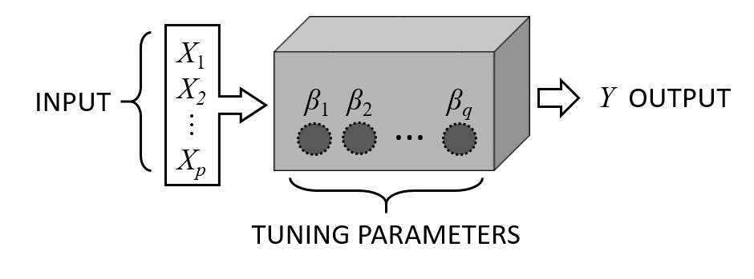

## Overfitting and Model Complexity

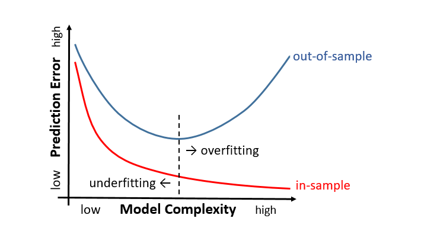

## Model Selection

- *Statistical Learning conundrum*: choose model based on *available data*, but want it to perform well on *unseen data*
  - In-sample performance favors overfitting
- Two practical ways to prevent overfitting
  - **Validation**
  - **Regularization**

## WDBC Data

- Tree with 100% in-sample accuracy

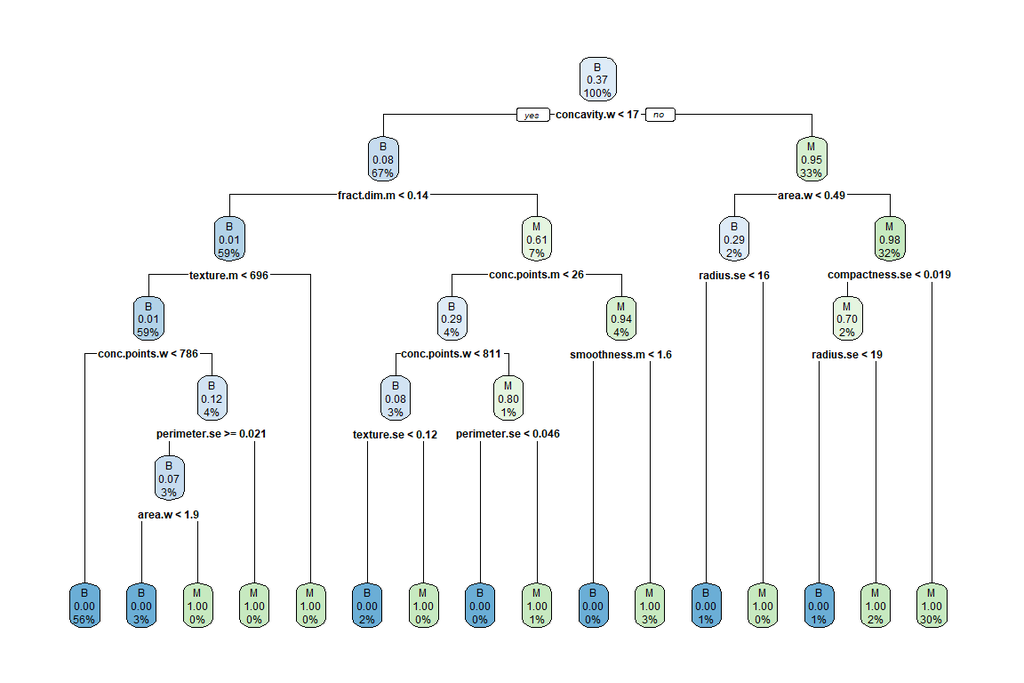

```r
big_tree = rpart( diagnosis ~ . - id, data = train,
               control = rpart.control(minsplit = 1, cp = 0) )
rpart.plot(big_tree)
```

## Validation Set

- Split data into training, validation, and test set
  - Fit competing models on training set
  - Select model based on validation set
  - Assess performance on test set

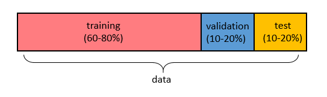

## WDBC Data

- Select tree model (# splits) with best validation performance

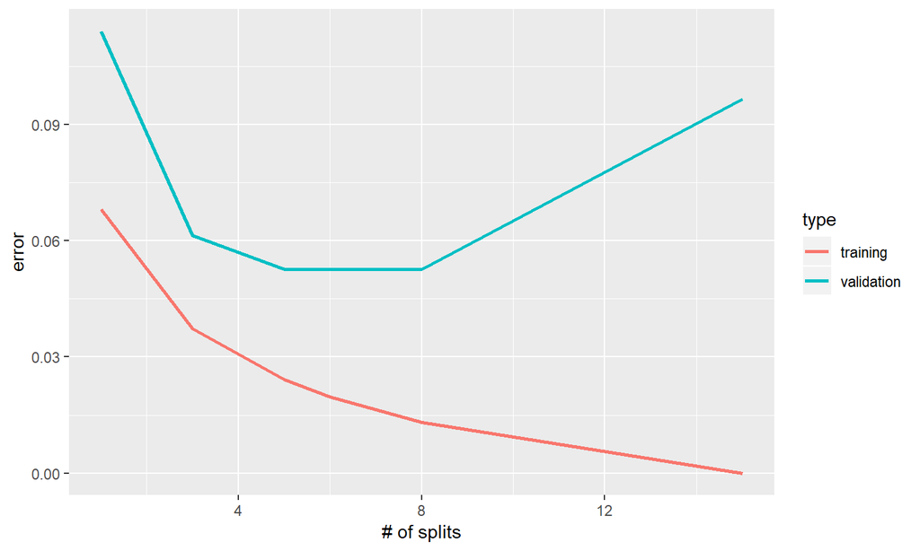

## Cross-Validation

- *Cross-Validation (CV)* repeatedly partitions data into training & validation sets
  - Iterations called *folds*
- Estimate performance by *averaging* error accross all folds

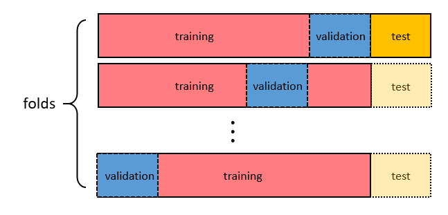

## WDBC Data

- CV performed by default in `rpart()`

```r
big_tree$cptable
##            CP nsplit  rel error    xerror       xstd
## 1 0.814371257      0 1.00000000 1.0000000 0.06156478
## 2 0.041916168      1 0.18562874 0.2634731 0.03775071
## 3 0.017964072      3 0.10179641 0.1976048 0.03312768
## 4 0.011976048      5 0.06586826 0.1676647 0.03069522
## 5 0.008982036      6 0.05389222 0.1497006 0.02910597
## 6 0.005988024      8 0.03592814 0.1377246 0.02798231
## 7 0.003992016     12 0.01197605 0.1137725 0.02555041
## 8 0.000000000     15 0.00000000 0.1257485 0.02679985
```

## WDBC Data

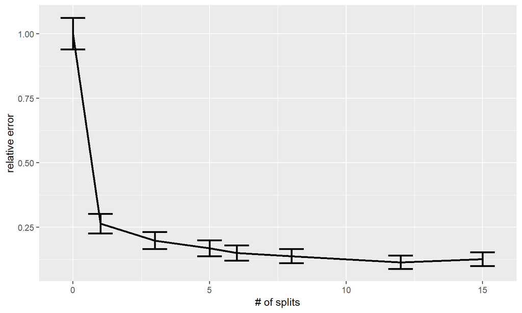

## Regularization

- Regularization is another way to estimate out-of-sample performance
- Regularization imposes **penalty on model complexity**
  - Choose model that minimizes  
    \[\text{(training error) + (complexity penalty)}\]
- Form of complexity penalty can vary
  - Specify based on theoretical results or cross-validation

## WDBC Data

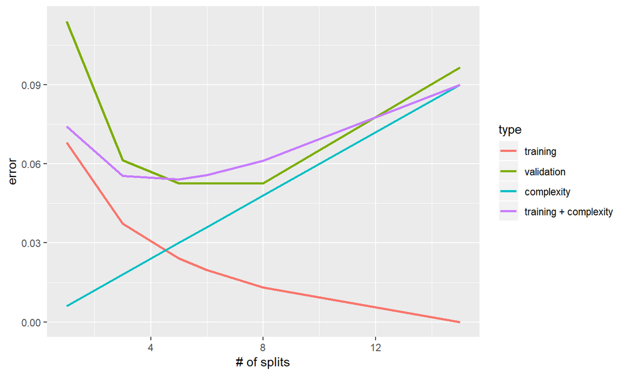

## Regularization

- For WDBC tree model
  - Training Error: 1 - accuracy
  - Complexity Penalty: \(cp\) * (# splits)
- Select model (*optimal* \(cp\)) based on
  - Minimum CV error, or
  - *Simplest* model within one st.dev. of min. CV error

## WDBC data

```r
as_tibble(big_tree$cptable ) %>%
  mutate( pick = (xerror <  min(xerror) + xstd ) )
## # A tibble: 8 x 6
##        CP nsplit `rel error` xerror   xstd pick
##     <dbl>  <dbl>       <dbl>  <dbl>  <dbl> <lgl>
## 1 0.814        0      1       1     0.0616 FALSE
## 2 0.0419       1      0.186   0.263 0.0378 FALSE
## 3 0.0180       3      0.102   0.198 0.0331 FALSE
## 4 0.0120       5      0.0659  0.168 0.0307 FALSE
## 5 0.00898      6      0.0539  0.150 0.0291 FALSE
## 6 0.00599      8      0.0359  0.138 0.0280 TRUE
## 7 0.00399     12      0.0120  0.114 0.0256 TRUE
## 8 0           15      0       0.126 0.0268 TRUE
```

## WDBC data

```r
final_tree = prune(big_tree, cp = .006)
test %>% add_predictions( final_tree, type = "class") %>%
  mutate( pred = fct_relevel(pred, "M"),
          diagnosis = fct_relevel(diagnosis, "M") ) %>%
  xtabs( ~ pred + diagnosis, data = .) %>% prop.table()
##     diagnosis
## pred          M          B
##    M 0.35964912 0.01754386
##    B 0.03508772 0.58771930
```

## WDBC data

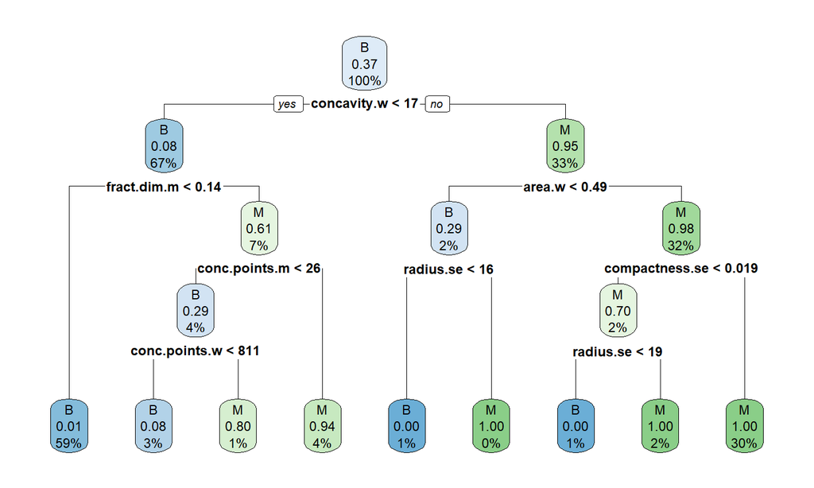

## Recipe for Statistical Learning

- Split data into training/training+validation & test set
- Fit models of different complexity on training set
- Choose *optimal* model complexity using regularization/cross-validation
- Estimate out-of-sample performance of *final* model on test set